# tableHTML

14 November 2019

## Contents

- Introduction
- Basic Options
- Themes
- Add CSS customizations
- Shiny

## Introduction

## Introduction: why, what, and how?

- While developing a [football app](https://lyzander.shinyapps.io/FootballeR/) using shiny, it was somewhat difficult to build a pretty HTML table
  - Example: drawing vertical lines every three columns seemed like a difficult task
  - even using great packages like `xtable`
- Development started in 2016
- tableHTML is a package for building CSS-ible HTML tables in an easy and intuitive way
- Compatible with any application that accepts HTML (e.g. shiny, rmarkdown, Outlook, PowerPoint, Word)

## Introduction

- The main function tableHTML converts a data.frame or matrix or any other object that can be converted into a data.frame into an HTML table

```r
mtcars[,1:3] %>% head(2)
#               mpg cyl disp
# Mazda RX4      21   6  160
# Mazda RX4 Wag  21   6  160
```

```html
<table style="border-collapse:collapse;"
        class=table_4805 border=1>
<thead>
<tr>
  <th id="tableHTML_header_1"> </th>
  <th id="tableHTML_header_2">mpg</th>
  <th id="tableHTML_header_3">cyl</th>
  <th id="tableHTML_header_4">disp</th>
</tr>
</thead>
<tbody>
<tr>
  <td id="tableHTML_rownames">Mazda RX4</td>
  <td id="tableHTML_column_1">21</td>
  <td id="tableHTML_column_2">6</td>
  <td id="tableHTML_column_3">160</td>
</tr>
<tr>
  <td id="tableHTML_rownames">Mazda RX4 Wag</td>
  <td id="tableHTML_column_1">21</td>
  <td id="tableHTML_column_2">6</td>
  <td id="tableHTML_column_3">160</td>
</tr>
</tbody>
</table>
```

## Introduction

- Using the function in RStudio will print the table in the viewer pane otherwise it will use the default browser, and
- the default tables are built without any CSS in order to allow for full flexibility.

[figure not shown]

## Introduction

- The package was developed so that the functions can be chained with the `%>%` (pipe) operator, exported from the package `magrittr`
- Tables can be exported as images using `tableHTML_to_image()`

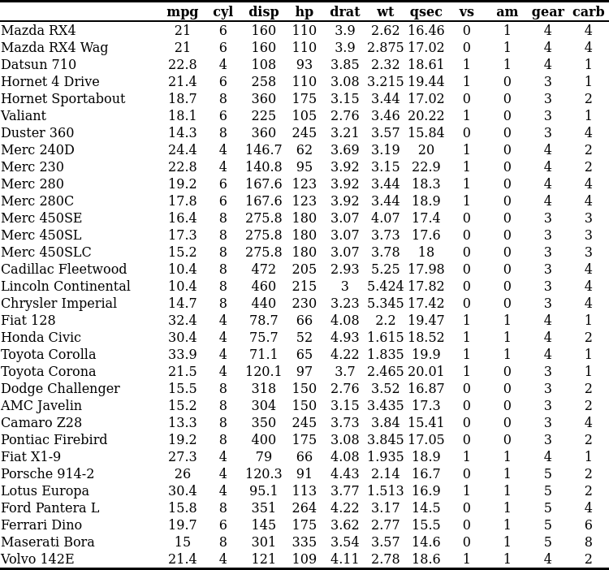

```r
mtcars %>%
  tableHTML(widths = c(200, rep(50, 11))) %>%
  add_theme('scientific') %>%
  tableHTML_to_image(
    file = 'img/tableHTML_to_image.png'
    )
```

## Basic Options

## Basic Options

- Right out of the bat the function `tableHTML()` offers a lot options to customize your table.
- Add a CSS class `class`
- Change the width of the columns `width`
- Adjust the thickness of the external borders `border`

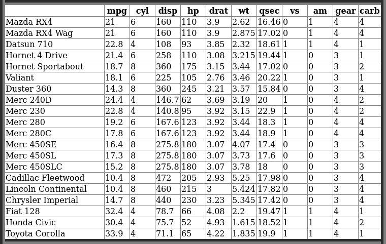

```r
mtcars %>%
  head(20) %>%
  tableHTML(class = 'table_0034',
            widths = c(200,
                       rep(50, ncol(mtcars))),
            border = 10)
```

## Basic Options

- Right out of the bat the function `tableHTML()` offers a lot options to customize your table.
- Add a second header `second_header`
- Add/remove row names `rownames`
- Add row groups `row_groups`

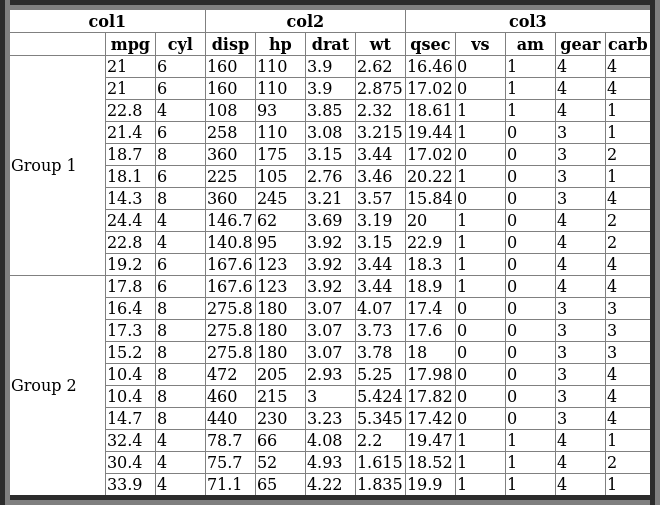

```r
mtcars %>%
  head(20) %>%
  tableHTML(second_headers =
              list(c(3, 4, 5),
                   c('col1', 'col2', 'col3')),
            rownames = FALSE,
            row_groups =
              list(c(10, 10),
                   c('Group 1', 'Group 2')),
            widths = c(100,
                       rep(50, ncol(mtcars))),
            border = 10)
```

## Basic Options

- Right out of the bat the function `tableHTML()` offers a lot of options to customize your table.
- Round numeric columns `round`
- Fill missing values `replace_NA`
- Add a caption above the table `caption`
- Add a footer `footer`
- Adjust the spacing between the cells of the table `collapse`, `spacing`

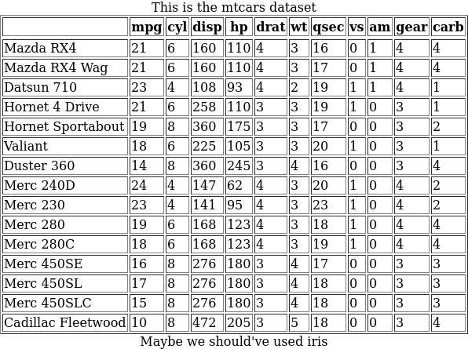

```r
mtcars %>%
  head(15) %>%
  tableHTML(round=0,
            caption =
              "This is the mtcars dataset",
            footer =
              "Maybe we should've used iris",
            collapse = 'separate')
```

## Themes

## Themes

- The package was built to give the users, the absolute freedom to design their own HTML tables,
- however, pre-defined themes are available for a fast stylization.
- Currently three main themes are available, and they can be added with the function `add_theme()`

## Themes

- `scientific`

```r
mtcars %>%
  head(10) %>%
  tableHTML() %>%
  add_theme('scientific')
```

- `rshiny-blue`

[figure not shown]

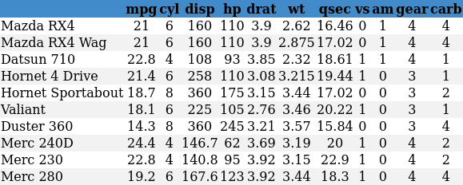

```r
mtcars %>%
  head(10) %>%
  tableHTML() %>%
  add_theme('rshiny-blue')
```

## Themes

- `colorize`

```r
mtcars %>%
  head(10) %>%
  tableHTML() %>%
  add_theme('colorize')
```

- `colorize` can also be customized, when added with the function `add_theme_colorize()`

[figure not shown]

```r
mtcars %>%
  head(10) %>%
  tableHTML() %>%
  add_theme_colorize(color=c('pink3', 'yellow2'))
```

- `colorize` with customized colors

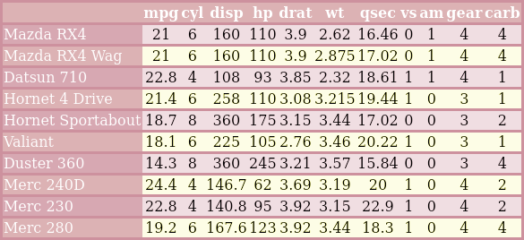

## Themes

- Also with `add_theme_colorize` the user can choose certain rows to highlight
  - e.g.: highlight the sum of quarterly sales

```r
df_q %>% head(8)
#    Month  x1  x2  x3
# 1    Jan   2  92  90
# 2    Feb  15  14  62
# 3    Mar  49  95  76
# 4   Sum1  66 201 228
# 5    Apr  51  69  98
# 6    May  38  28  30
# 7    Jun  75  38  24
# 8   Sum2 164 135 152
```

[figure not shown]

```r
df_q %>%
  tableHTML(widths = rep(50, 5),
            rownames = FALSE,
            row_groups = list(c(4, 4, 4, 4),
                              c('Q1', 'Q2', 'Q3', 'Q4'))) %>%
  add_theme_colorize(color = '#009999',
                     total_rows = c(4, 8, 12, 16))
```

## Add CSS customizations

## Add CSS customizations

- The `add_css_...` family of functions adds inline CSS to the HTML table.
  - `add_css_header`
  - `add_css_seconder_header`
  - `add_css_thead` (headers and second headers)
  - `add_css_tbody` (to all table apart from the headers and second headers.)
  - `add_css_table`
  - `add_css_caption`
  - `add_css_footer`
  - `add_css_row`
  - `add_css_column`
  - `add_css_conditional_column`

## Add CSS customizations

- The CSS code is added within the HTML table.

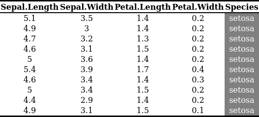

[figure not shown]

- stylize columns

```r
iris %>%
    head(10) %>%
    tableHTML(rownames = FALSE) %>%
    add_theme('scientific') %>%
    add_css_column(
        css = list(c('background-color', 'color'),
                   c('gray', 'white')),
        columns = 'Species')
```

- stylize rows

```r
iris %>%
    head(10) %>%
    tableHTML(rownames = FALSE) %>%
    add_css_row(
        css = list(c('background-color', 'color'),
                   c('purple', 'white')),
        rows = odd(1:nrow(iris)))
```